# Lab 2

Spicy Bois

2019/9/6

## Team Details

- Team Name - Spicy Bois

[figure not shown]

- I would like to be able to see how much movies make based on budget and actors.
- 6 months after I graduate I would like to be looking for a job and exploring for what to do with my degree. At 5 years I would like to be working in a field that relates to by degree that I enjoy
- I hope to lead a team in my career or be some kind of a manager/lead for a company.
- In this course I hope to learn what data science is so I can see if I want to choose it as my major.
- I really enjoy movies.

## About Trent

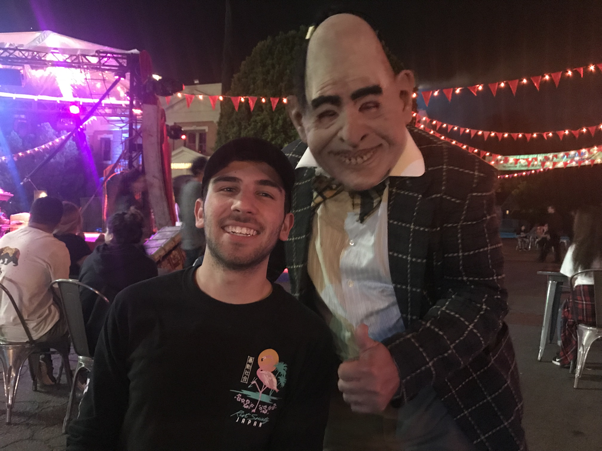

- Similar to Tyler, I would also be interested in applying data science to film, but more specifically on marketing and expenses of films.
- 6 months after I graduate I hope to be at somr sort of start up position at a company I like, and at 5 years I would like to hopefully be at the same job, or on a steady career path.
- I’m not sure if I have a specific goal for my “greatest career accomplishment” yet, but I hope it will ultimatly be something fufilling that I enjoy doing.
- In this course, I hope to learn about how to apply data science knowledge that we learn to tangible data sets, as well as learn new tools to work with data (R).
- I am also a bit of a cinefile, and I enjoy skiing and roller coasters

## About Logan

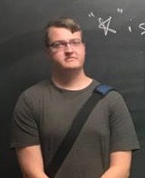

- By analyzing data, i would like to know the what breed a dog is based on an image.
- Six mounths after graduation I will love to be working as a prgramer working on AI. After 5 years, I would like to be doing the same thing just getting paid more.
- I would like my greatest career accomplishment to work an AI that is significantly more advance then current AI’s.
- I would like to leans the basics of data science, since data science is a big part of machine learning.
- I would love to work on the AI that lands rockets, seen by Space X.